# An idea for final project: Predicting one country’s economics by other countries’ economic indicators

Yushi Suma

2019/5/16

# 1 Idea

## 1.1 Basic idea

- Regress a country’s economic indicator (eg. GDP growth) on other countries indictors (eg. GDP growth).

## 1.2 Data

- IMF/World Economic Outlook (WEO) Data
  - [Front page](https://www.imf.org/external/pubs/ft/weo/2019/01/weodata/index.aspx)

## 1.3 My impression

- I’m just curious about it, but I don’t know if it is meaningful in light of economic theory.
- I conducted preliminary analysis as below, but I don’t know if there will be more interesting findings if we dig into the data.
- Also, I’m not sure such macroeconomic and time-series data is suieted for this course.

# 2 Preliminary analsis

## 2.2 Data

### 2.2.1 Data size

- The dimension of data is log GDP (PPP) of 194 countries (observations) X 39 years (columns), and I used the data of 144 countries which have no NAs.

### 2.2.2 Data source

- The csv file I used for this preliminary analysis is generated by the excel file downloaded from here

### 2.2.3 Note

- The number of columns might not be large enough for the purpose of this assignment, but other non-GDP indicators (such as population, unemployment rate, trade/GDP ratio, etc) can be added on the IMF website too. So, we can easily increase the columns (although I’m not sure it is meaningful).

# 3 Preliminary analysis result

## 3.1 Data loading and distribution of GDP

```r
library(tidyverse)
library(here)
library(broom)
library(furrr)    # for parallel purrr
plan(multiprocess)
library(gamlr)

set.seed(12345)
```

```r
data <- read_csv(here("Data/WEO_Data.csv"),
                 na = "n/a",
                 col_types = str_c("ccccc", str_flatten(rep("n", 2018 - 1980 + 1)), "_"))
GDP_USD <- data %>%
  filter(`Subject Descriptor` == "Gross domestic product, current prices",
         Units == "U.S. dollars")

GDP_PPP <- data %>%
  filter(`Subject Descriptor` == "Gross domestic product, current prices",
         Units == "Purchasing power parity; international dollars")

CA <- data %>%
  filter(`Subject Descriptor` == "Current account balance")
```

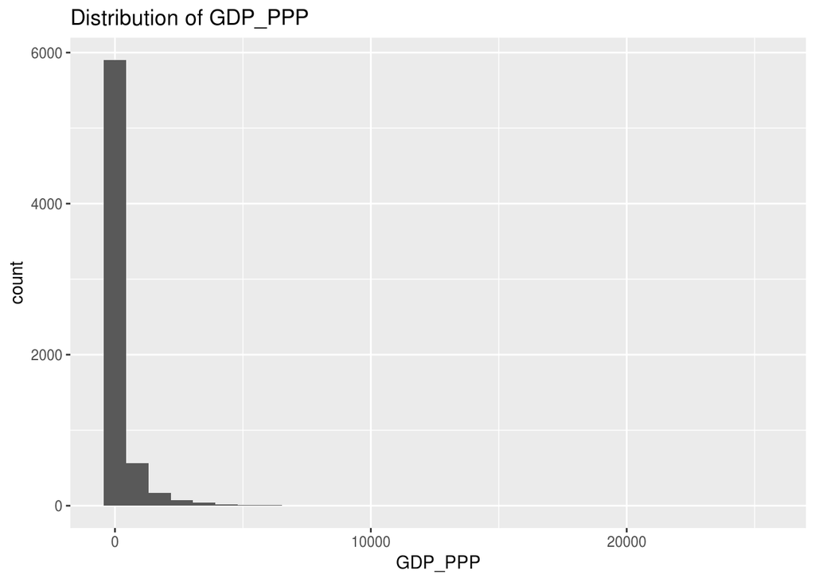

```r
tidy_GDP_PPP <-
  GDP_PPP %>%
  select(-(2:5)) %>%
  gather(key = "year", value = "GDP_PPP", -1) %>%
  group_by(Country) %>%
  arrange(Country, year) %>%
  mutate(log_GDP_PPP = log(GDP_PPP),
         diff_log_GDP_PPP = log_GDP_PPP - lag(log_GDP_PPP),
         growth_rate = GDP_PPP / lag(GDP_PPP))

# distribution of GDP_PPP
tidy_GDP_PPP %>%
  ggplot(aes(x = GDP_PPP)) + geom_histogram() +
    labs(title = "Distribution of GDP_PPP")
```

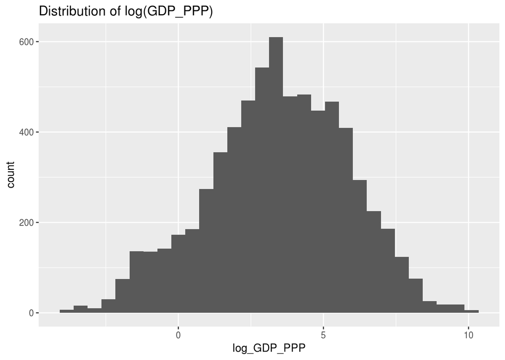

```r
# distribution of log_GDP_PPP
tidy_GDP_PPP %>%
  ggplot(aes(x = log_GDP_PPP)) + geom_histogram() +
    labs(title = "Distribution of log(GDP_PPP)")
```

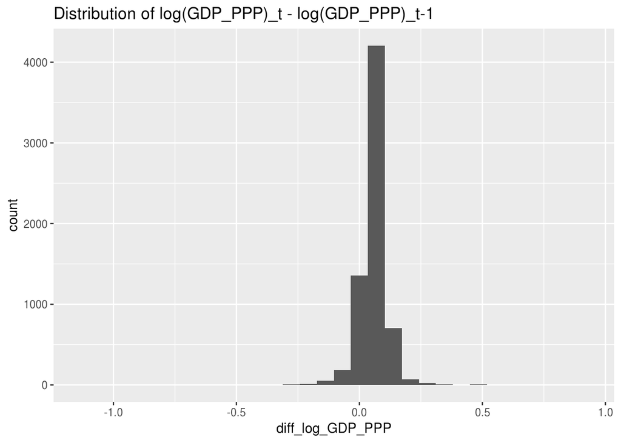

```r
# distribution of diff_log_GDP_PPP
tidy_GDP_PPP %>%
  ggplot(aes(x = diff_log_GDP_PPP)) + geom_histogram()+
    labs(title = "Distribution of log(GDP_PPP)_t - log(GDP_PPP)_t-1")
```

```r
NAlist_sparse_GDP_PPP <- # countries that includes more than 1 NAs
  tidy_GDP_PPP %>%
  select(1, 2, 5) %>%    # select diff_log_GDP_PPP only
  mutate(isNA = is.na(diff_log_GDP_PPP)) %>%
  group_by(Country) %>%
  summarise(sumNA = sum(isNA)) %>%
  filter(sumNA > 1)

sparse_GDP_PPP <-
  tidy_GDP_PPP %>%
  select(1, 2, 5) %>%    # select diff_log_GDP_PPP only
  filter(!(Country %in% NAlist_sparse_GDP_PPP$Country)) %>% # exlude countries which include NAs
  spread(key = "Country", value = "diff_log_GDP_PPP") %>%
  filter(year != 1980)

sparse_GDP_PPP_after1990 <-
  tidy_GDP_PPP %>%
  select(1, 2, 5) %>%    # select diff_log_GDP_PPP only
  filter(!(Country %in% NAlist_sparse_GDP_PPP$Country)) %>% # exlude countries which include NAs
  spread(key = "Country", value = "diff_log_GDP_PPP") %>%
  filter(year != 1980, year >= 1990)
```

## 3.2 LASSO and CV-LASSO for all data (1981-2018)

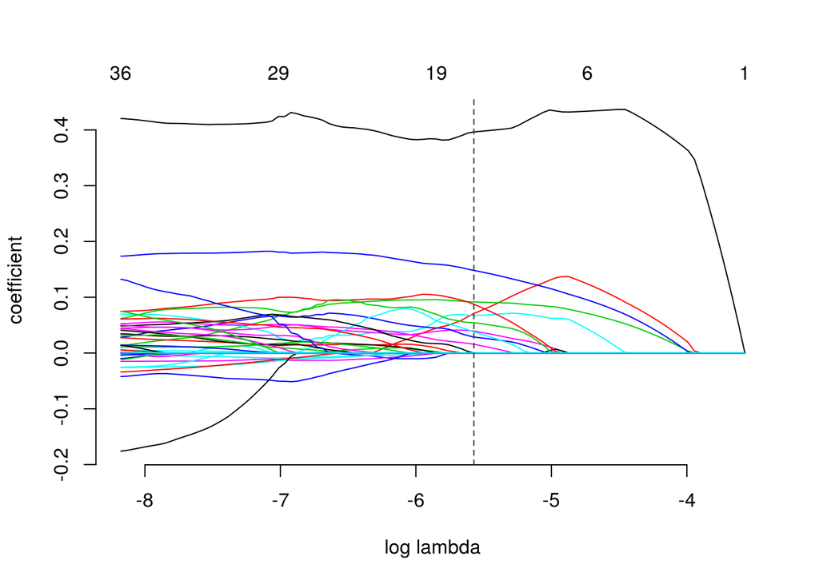

```r
# JP LASSO
reg_JP <- lm(Japan ~ ., data = sparse_GDP_PPP %>% select(-1))

lasso_JP <- gamlr(x = sparse_GDP_PPP %>% select(-1) %>% select(-Japan),
                  y = sparse_GDP_PPP %>% select(Japan))

plot(lasso_JP)
```

```r
seg_JP <- names(AICc(lasso_JP))[which.min(AICc(lasso_JP))]
(coef_JP <-
  coef(lasso_JP) %>% as.matrix() %>% data.frame() %>% rownames_to_column() %>%
  rename(estimate = !!seg_JP) %>%
  filter(estimate != 0))
```

```
##          rowname    estimate
## 1      intercept -0.01327939
## 2       Botswana  0.09158902
## 3        Germany  0.06705522
## 4          Italy  0.39644091
## 5          Kenya  0.08750866
## 6      Mauritius  0.02865626
## 7         Norway  0.03774645
## 8           Oman  0.03932857
## 9       Pakistan  0.07094445
## 10      Thailand  0.14806845
## 11        Turkey  0.01568380
## 12 United States  0.05445367
```

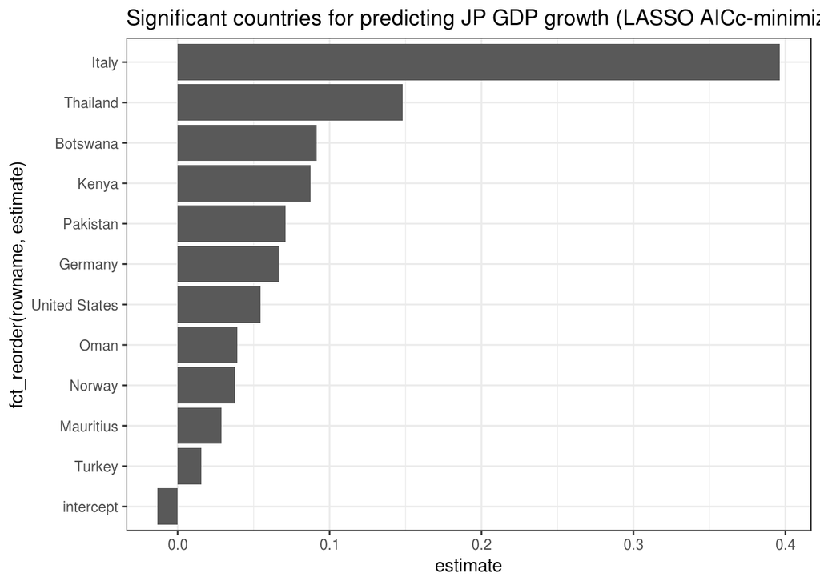

```r
coef_JP %>%
  ggplot(aes(x = fct_reorder(rowname, estimate), y = estimate)) +
  geom_col() +
  labs(title = "Significant countries for predicting JP GDP growth (LASSO AICc-minimizing lambda)") +
  coord_flip() +
  theme_bw()
```

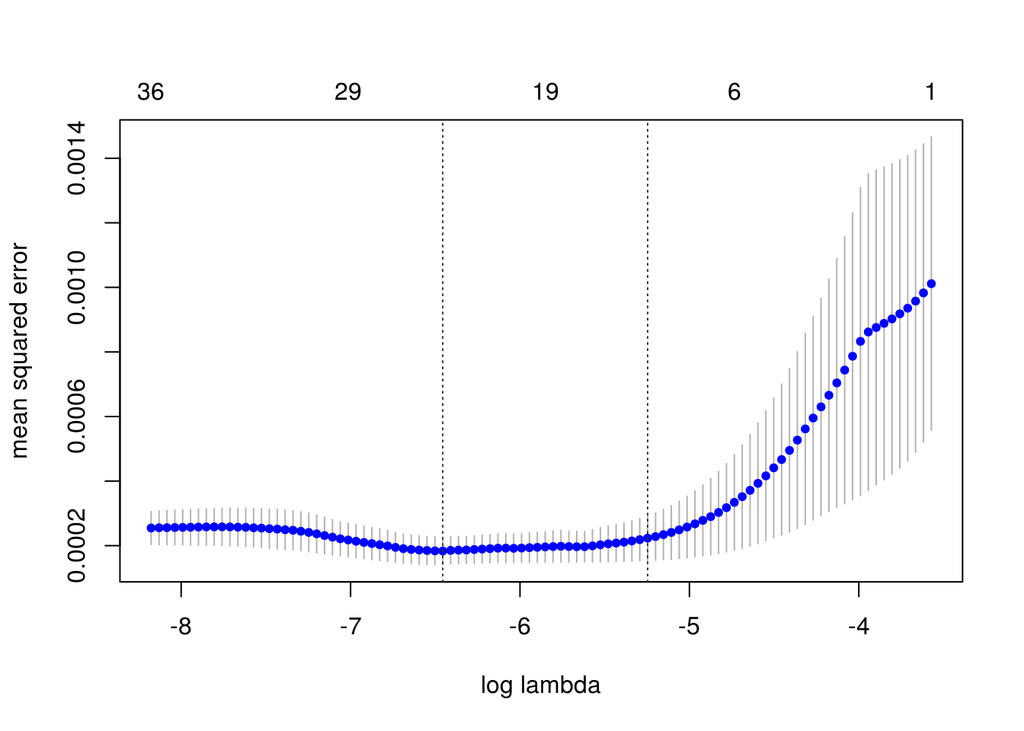

```r
# JP CV-LASSO
cv.lasso_JP <- cv.gamlr(x = sparse_GDP_PPP %>% select(-1) %>% select(-Japan),
                  y = sparse_GDP_PPP %>% select(Japan))

plot(cv.lasso_JP)
```

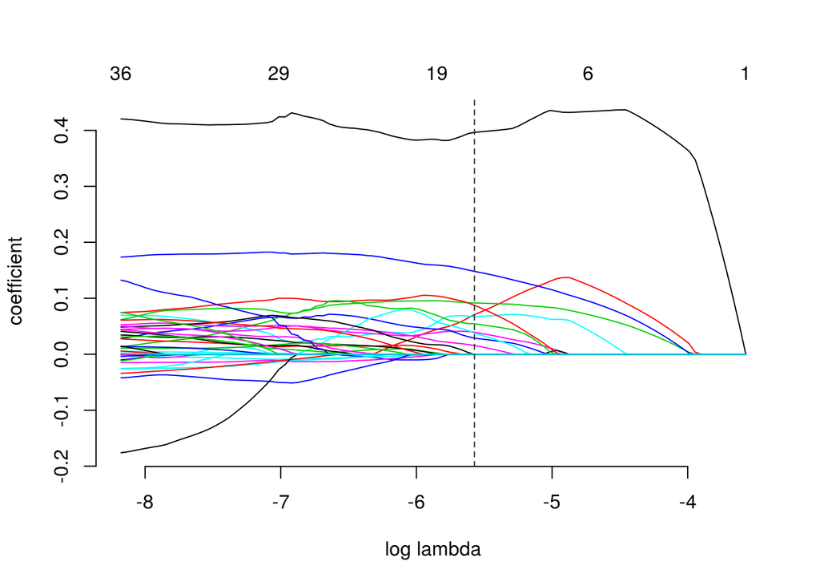

```r
plot(cv.lasso_JP$gamlr)
```

```r
seg_JP <- str_c("seg", cv.lasso_JP$seg.1se)
(coef_cv_JP <-
  coef(cv.lasso_JP, select = "1se") %>% as.matrix() %>% data.frame() %>% rownames_to_column() %>%
  rename(estimate = !!seg_JP) %>%
  filter(estimate != 0))
```

```
##          rowname     estimate
## 1      intercept -0.007287774
## 2       Botswana  0.088526941
## 3        Germany  0.070914410
## 4          Italy  0.407891679
## 5          Kenya  0.048385198
## 6      Mauritius  0.017203479
## 7         Norway  0.010039241
## 8           Oman  0.024268406
## 9       Pakistan  0.107177277
## 10      Thailand  0.130395676
## 11 United States  0.040411444
```

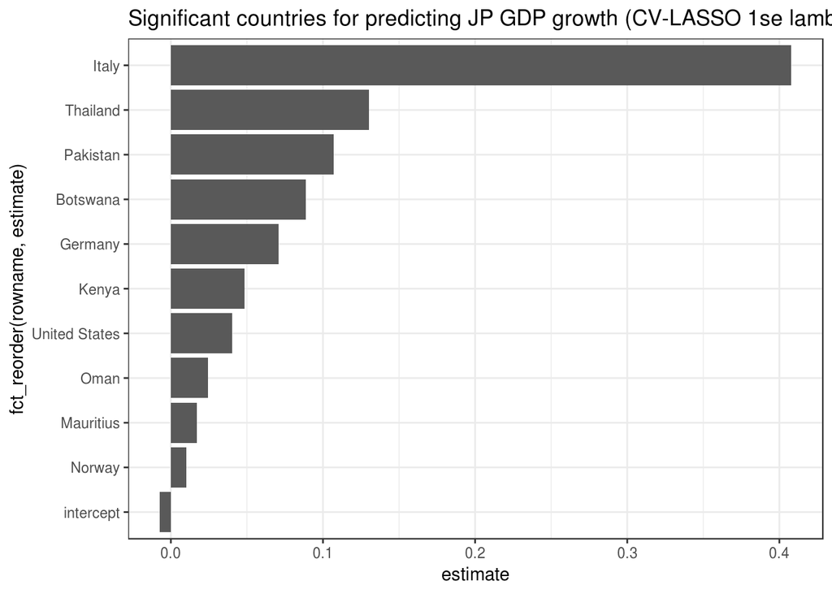

```r
coef_cv_JP %>%
  ggplot(aes(x = fct_reorder(rowname, estimate), y = estimate)) +
  geom_col() +
  labs(title = "Significant countries for predicting JP GDP growth (CV-LASSO 1se lambda)") +
  coord_flip() +
  theme_bw()
```

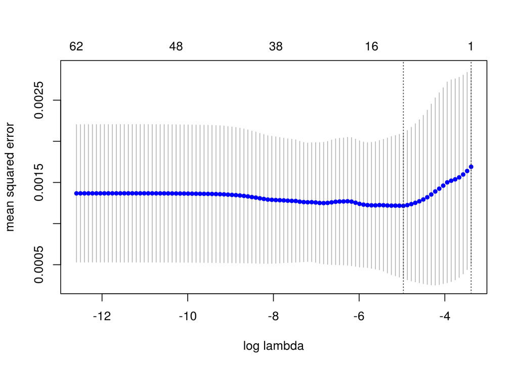

```r
# Indonesia
reg_ID <- lm(Indonesia ~ ., data = sparse_GDP_PPP %>% select(-1))
cv.lasso_ID <- cv.gamlr(x = sparse_GDP_PPP %>% select(-1) %>% select(-Indonesia),
                  y = sparse_GDP_PPP %>% select(Indonesia),
                  lambda.min.ratio = 1e-4)

plot(cv.lasso_ID)
```

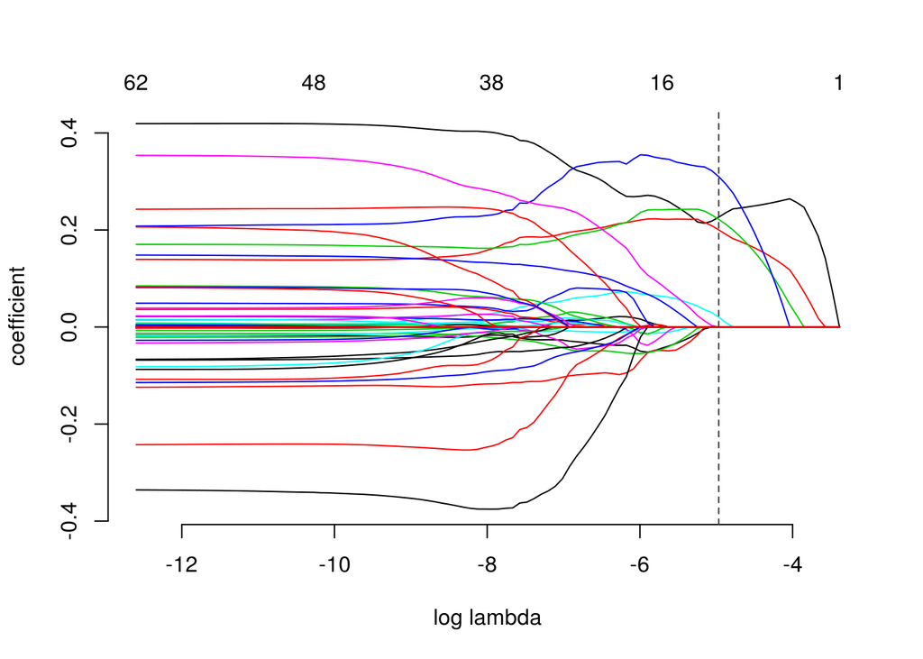

```r
plot(cv.lasso_ID$gamlr)
```

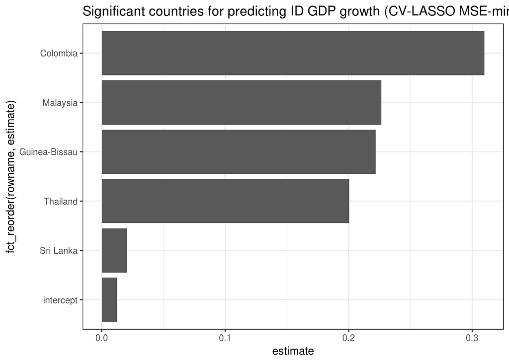

```r
seg_ID <- str_c("seg", cv.lasso_ID$seg.min)

coef_ID <-
  coef(cv.lasso_ID, select = "min") %>% as.matrix() %>% data.frame() %>% rownames_to_column() %>%
  rename(estimate = !!seg_ID) %>%
  filter(estimate != 0)
coef_ID %>% ggplot(aes(x = fct_reorder(rowname, estimate), y = estimate)) +
  geom_col() +
  labs(title = "Significant countries for predicting ID GDP growth (CV-LASSO MSE-minimizing lambda)") +
  coord_flip() +
  theme_bw()
```

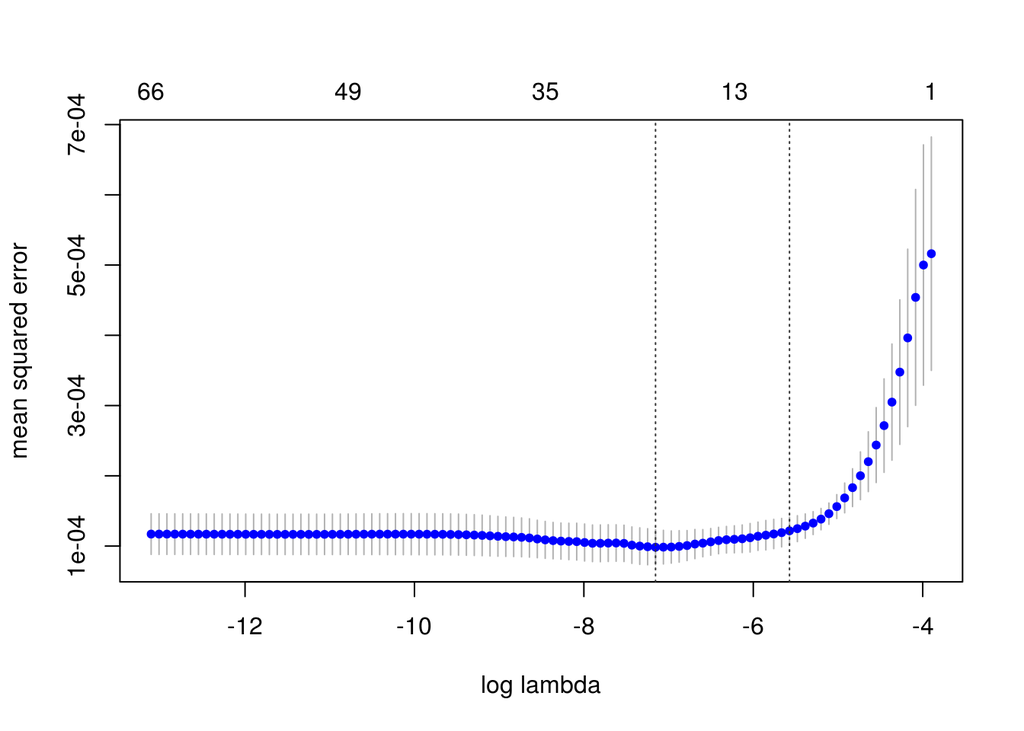

```r
# US
reg_US <- lm(`United States` ~ ., data = sparse_GDP_PPP %>% select(-1))
cv.lasso_US <- cv.gamlr(x = sparse_GDP_PPP %>% select(-1) %>% select(-`United States`),
                  y = sparse_GDP_PPP %>% select(`United States`),
                  lambda.min.ratio = 1e-4)

plot(cv.lasso_US)
```

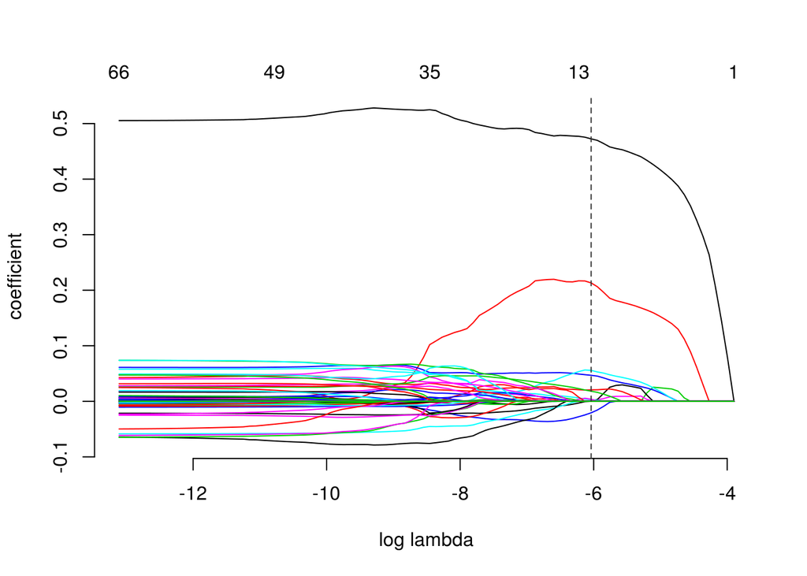

```r
plot(cv.lasso_US$gamlr)
```

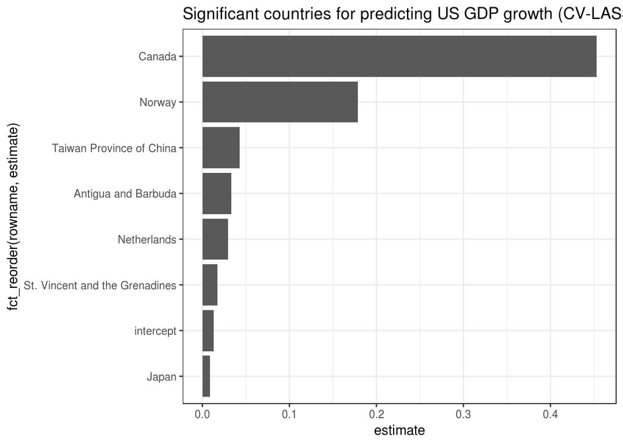

```r
seg_US <- str_c("seg", cv.lasso_US$seg.1se)

coef_US <-
  coef(cv.lasso_US, select = "1se") %>% as.matrix() %>% data.frame() %>% rownames_to_column() %>%
  rename(estimate = !!seg_US) %>%
  filter(estimate != 0)
coef_US %>% ggplot(aes(x = fct_reorder(rowname, estimate), y = estimate)) +
  geom_col() +
  labs(title = "Significant countries for predicting US GDP growth (CV-LASSO 1se lambda)") +
  coord_flip() +
  theme_bw()
```

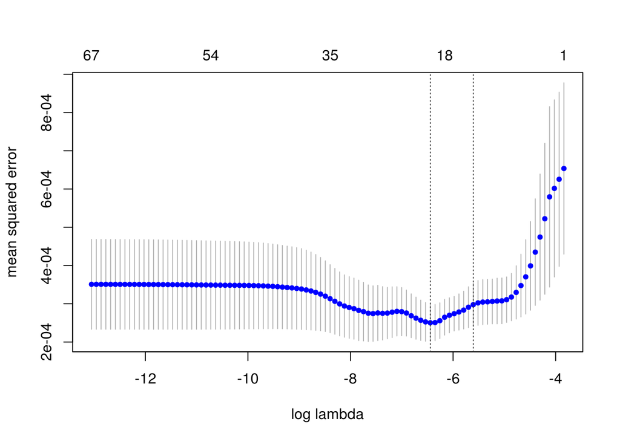

```r
# Germaney
reg_DE <- lm(Germany ~ ., data = sparse_GDP_PPP %>% select(-1))
cv.lasso_DE <- cv.gamlr(x = sparse_GDP_PPP %>% select(-1) %>% select(-Germany),
                  y = sparse_GDP_PPP %>% select(Germany),
                  lambda.min.ratio = 1e-4)

plot(cv.lasso_DE)
```

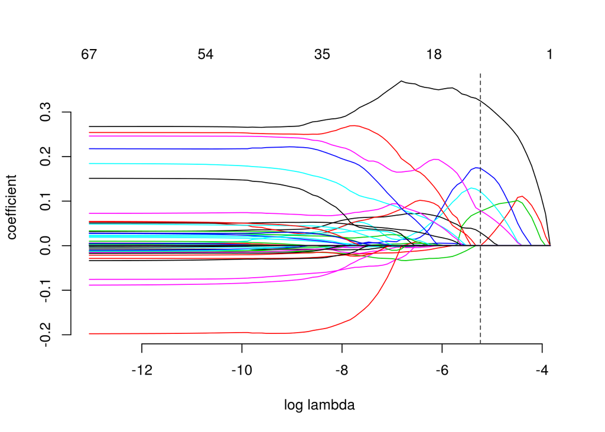

```r
plot(cv.lasso_DE$gamlr)
```

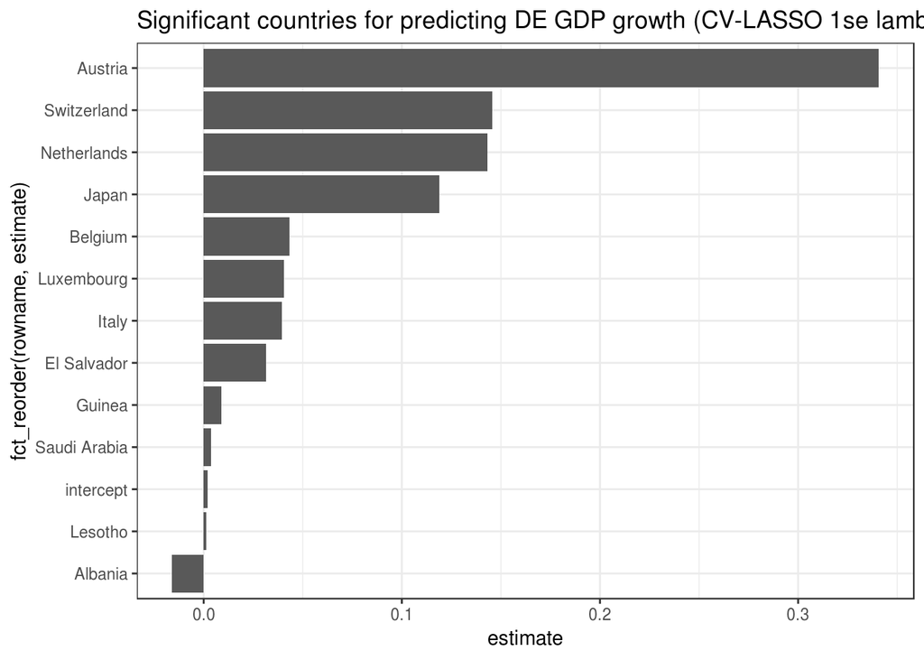

```r
seg_DE <- str_c("seg", cv.lasso_DE$seg.1se)

coef_DE <-
  coef(cv.lasso_DE, select = "1se") %>% as.matrix() %>% data.frame() %>% rownames_to_column() %>%
  rename(estimate = !!seg_DE) %>%
  filter(estimate != 0)
coef_DE %>% ggplot(aes(x = fct_reorder(rowname, estimate), y = estimate)) +
  geom_col() +
  labs(title = "Significant countries for predicting DE GDP growth (CV-LASSO 1se lambda)") +
  coord_flip() +
  theme_bw()
```

## 3.3 LASSO and CV-LASSO for after 1990 (1990-2018)

### 3.3.1 LASSO (Japan)

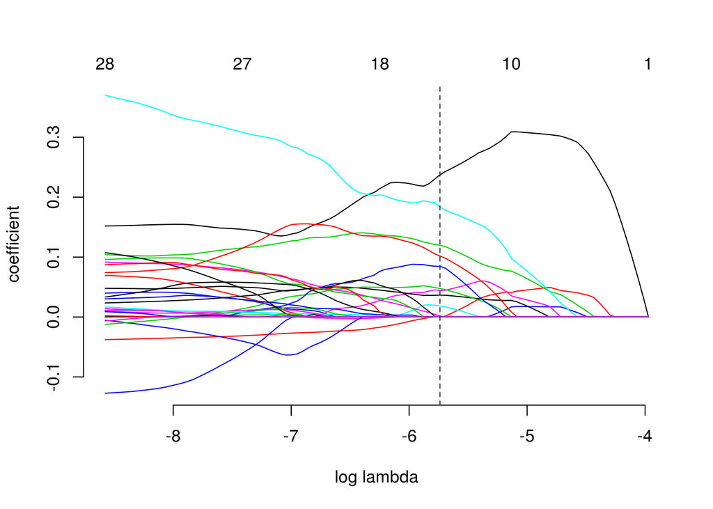

```r
# JP LASSO
reg_JP <- lm(Japan ~ ., data = sparse_GDP_PPP_after1990 %>% select(-1))

lasso_JP <- gamlr(x = sparse_GDP_PPP_after1990 %>% select(-1) %>% select(-Japan),
                  y = sparse_GDP_PPP_after1990 %>% select(Japan))

plot(lasso_JP)
```

```r
seg_JP <- names(AICc(lasso_JP))[which.min(AICc(lasso_JP))]
(coef_JP <-
  coef(lasso_JP) %>% as.matrix() %>% data.frame() %>% rownames_to_column() %>%
  rename(estimate = !!seg_JP) %>%
  filter(estimate != 0))
```

```
##         rowname     estimate
## 1     intercept -0.008757779
## 2      Botswana  0.018498603
## 3      Eswatini  0.044206706
## 4         Gabon  0.001712854
## 5       Germany  0.237239177
## 6         Italy  0.183442053
## 7        Norway  0.084352535
## 8   Philippines  0.101654110
## 9  Saudi Arabia  0.047461039
## 10     Thailand  0.119733920
## 11       Turkey  0.036520468
```

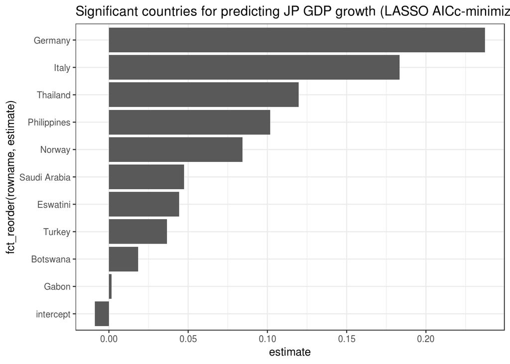

```r
coef_JP %>%
  ggplot(aes(x = fct_reorder(rowname, estimate), y = estimate)) +
  geom_col() +
  labs(title = "Significant countries for predicting JP GDP growth (LASSO AICc-minimizing lambda)") +
  coord_flip() +
  theme_bw()
```

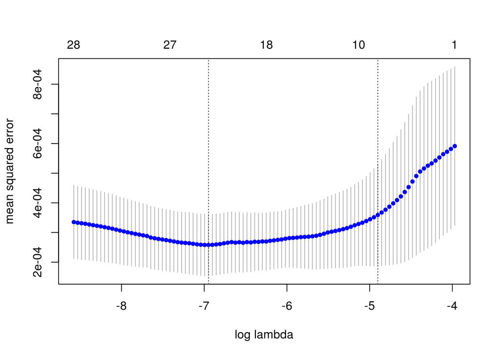

```r
# JP CV-LASSO
cv.lasso_JP <- cv.gamlr(x = sparse_GDP_PPP_after1990 %>% select(-1) %>% select(-Japan),
                  y = sparse_GDP_PPP_after1990 %>% select(Japan))

plot(cv.lasso_JP)
```

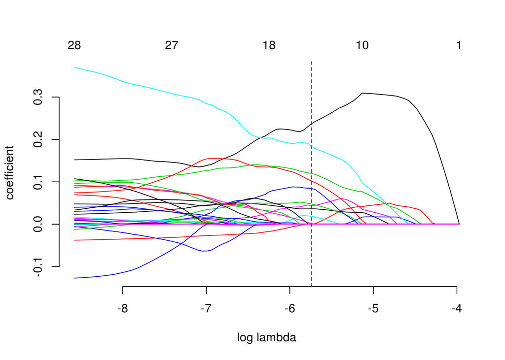

```r
plot(cv.lasso_JP$gamlr)
```

```r
seg_JP <- str_c("seg", cv.lasso_JP$seg.1se)
(coef_cv_JP <-
  coef(cv.lasso_JP, select = "1se") %>% as.matrix() %>% data.frame() %>% rownames_to_column() %>%
  rename(estimate = !!seg_JP) %>%
  filter(estimate != 0))
```

```
##                rowname    estimate
## 1            intercept 0.008449510
## 2             Eswatini 0.023267972
## 3              Germany 0.305985211
## 4                Italy 0.059904264
## 5             Malaysia 0.047368198
## 6             Thailand 0.053262506
## 7               Turkey 0.009176347
## 8 United Arab Emirates 0.017167224
```

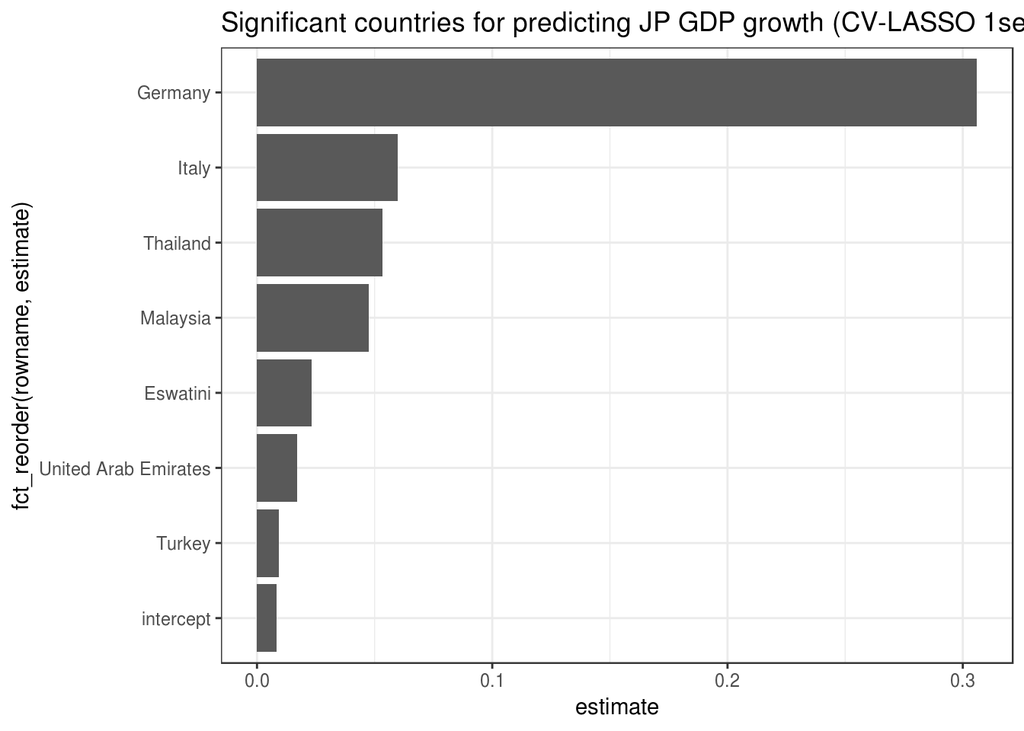

```r
coef_cv_JP %>%
  ggplot(aes(x = fct_reorder(rowname, estimate), y = estimate)) +
  geom_col() +
  labs(title = "Significant countries for predicting JP GDP growth (CV-LASSO 1se lambda)") +
  coord_flip() +
  theme_bw()
```

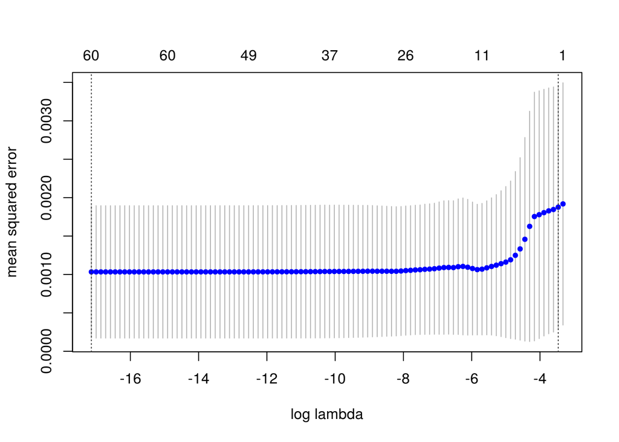

```r
# Indonesia
reg_ID <- lm(Indonesia ~ ., data = sparse_GDP_PPP_after1990 %>% select(-1))
cv.lasso_ID <- cv.gamlr(x = sparse_GDP_PPP_after1990 %>% select(-1) %>% select(-Indonesia),
                  y = sparse_GDP_PPP_after1990 %>% select(Indonesia),
                  lambda.min.ratio = 1e-6)

plot(cv.lasso_ID)
```

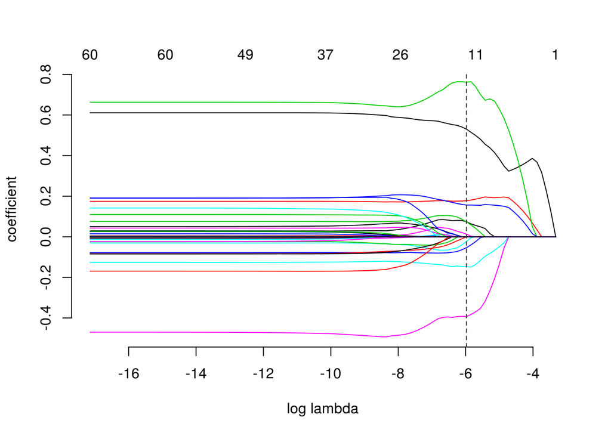

```r
plot(cv.lasso_ID$gamlr)
```

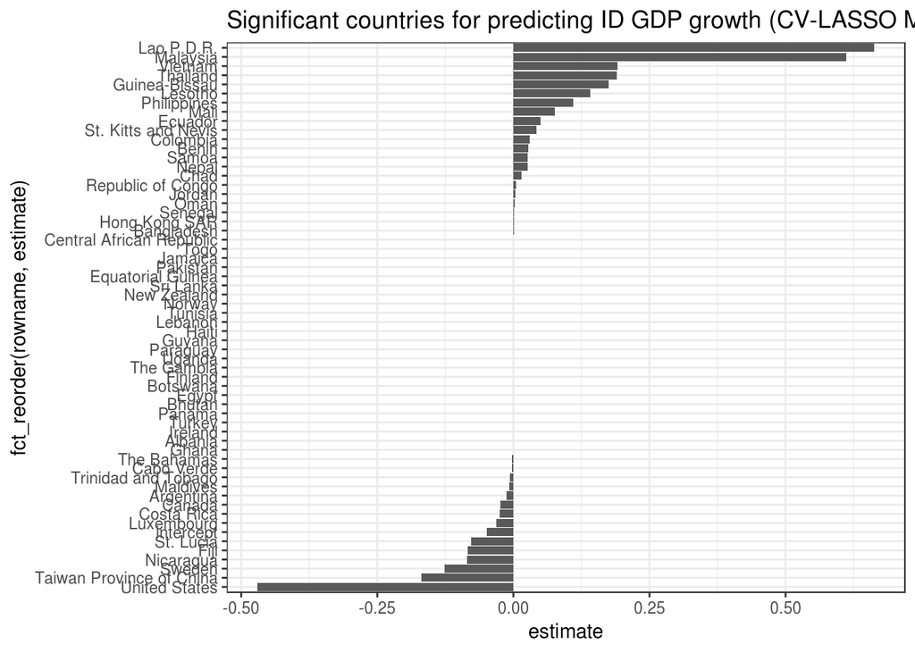

```r
seg_ID <- str_c("seg", cv.lasso_ID$seg.min)

coef_ID <-
  coef(cv.lasso_ID, select = "min") %>% as.matrix() %>% data.frame() %>% rownames_to_column() %>%
  rename(estimate = !!seg_ID) %>%
  filter(estimate != 0)
coef_ID %>% ggplot(aes(x = fct_reorder(rowname, estimate), y = estimate)) +
  geom_col() +
  labs(title = "Significant countries for predicting ID GDP growth (CV-LASSO MSE-minimizing lambda)") +
  coord_flip() +
  theme_bw()
```

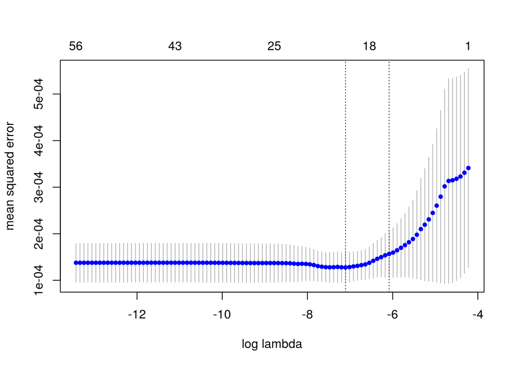

```r
# US
reg_US <- lm(`United States` ~ ., data = sparse_GDP_PPP_after1990 %>% select(-1))
cv.lasso_US <- cv.gamlr(x = sparse_GDP_PPP_after1990 %>% select(-1) %>% select(-`United States`),
                  y = sparse_GDP_PPP_after1990 %>% select(`United States`),
                  lambda.min.ratio = 1e-4)

plot(cv.lasso_US)
```

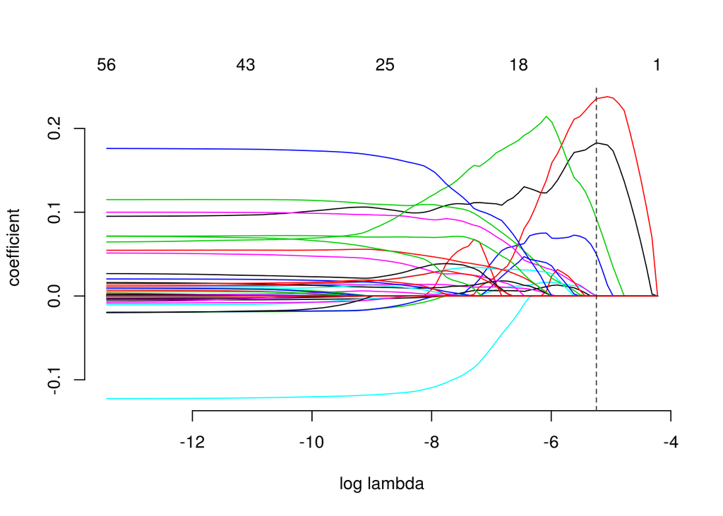

```r
plot(cv.lasso_US$gamlr)
```

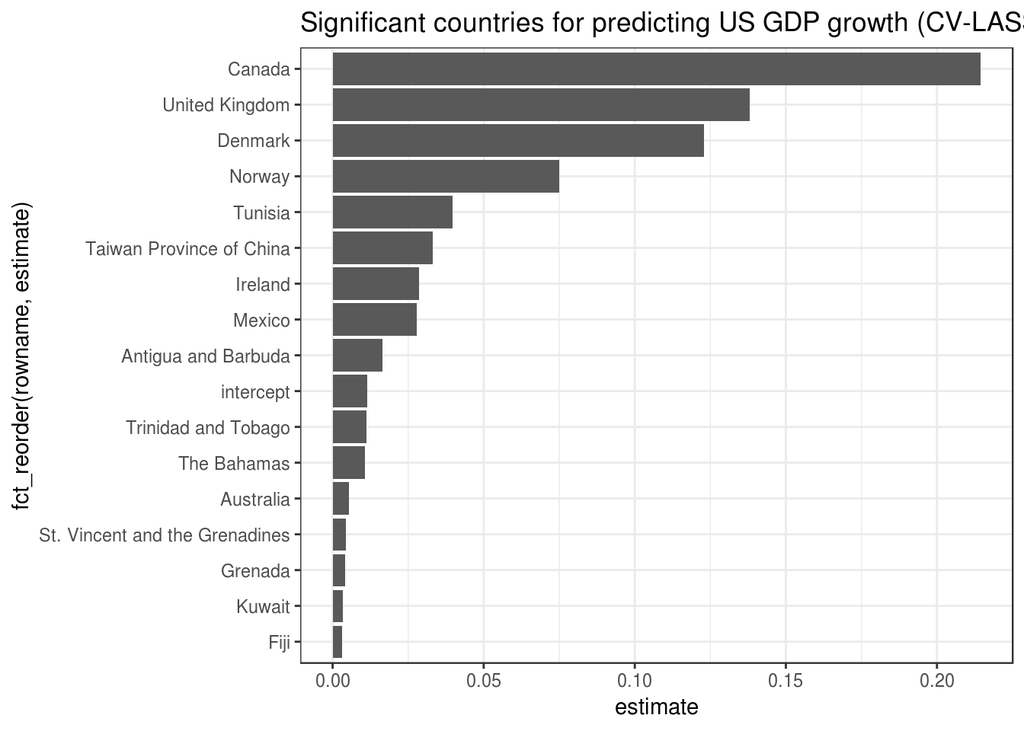

```r
seg_US <- str_c("seg", cv.lasso_US$seg.1se)

coef_US <-
  coef(cv.lasso_US, select = "1se") %>% as.matrix() %>% data.frame() %>% rownames_to_column() %>%
  rename(estimate = !!seg_US) %>%
  filter(estimate != 0)
coef_US %>% ggplot(aes(x = fct_reorder(rowname, estimate), y = estimate)) +
  geom_col() +
  labs(title = "Significant countries for predicting US GDP growth (CV-LASSO 1se lambda)") +
  coord_flip() +
  theme_bw()
```